# Modeling and prediction for movies, by Christopher Spangler

## Setup

### Load packages

```r
library(ggplot2)
library(dplyr)
library(statsr)
```

### Load data

```r
load("_e1fe0c85abec6f73c72d73926884eaca_movies.Rdata")
```

## Part 1: Data

The Data from this observational study is made up of 651 randomly sampled movies produced and released before 2016. It includes data from Rotten Tomatoes and the Internet Movie Database (IMDB). This is not an experiment. It should be noted that much of this data, such as audience and critic scores, is subjective, and while one person might find a movie to be a “good movie,”" another person might find the same movie to be “mediocre” or even downright “bad.” This also implies that a non-causal attitude/viewpoint be taken, as viewpoints are relative and not absolute. Only associations can be shown, and, hence, causality cannot be shown.

## Part 2: Research question

What attributes might make a movie that we could accurately predict the score on the IMDb from the Rotten tomatoes score? I would trust IMDb more than Rotten Tomatoes website, as IMDb has substantially more data and more reviews, more input, etc.

I would argue that genre, runtime, rating, critics score and audience score would accurately predict the IMDb score for a movie

## Part 3: Exploratory data analysis

For our Multiple Linear Regression model, let’s consider the variables to use: We have already made the assumption that the critics’ score might be determine the IMDb score, so we should include that. In fact, imdb_rating is the key dependent, investigative variable that we are trying to find out and, effectively, maximize in our model.

For our EDA, let’s check the correlation coefficient “R” for imdb_rating and critics_score, our key relationship:

```r
movies %>%
summarize(cor(critics_score, imdb_rating))
```

```
## # A tibble: 1 × 1
##   `cor(critics_score, imdb_rating)`
##                               <dbl>
## 1                         0.7650355
```

So we have a relatively strong correlation, as its absolute value is above .6 (a general, but not necessary, rule of thumb for Pearson’s R). Let’s see if a plot can shed some light on the situation:

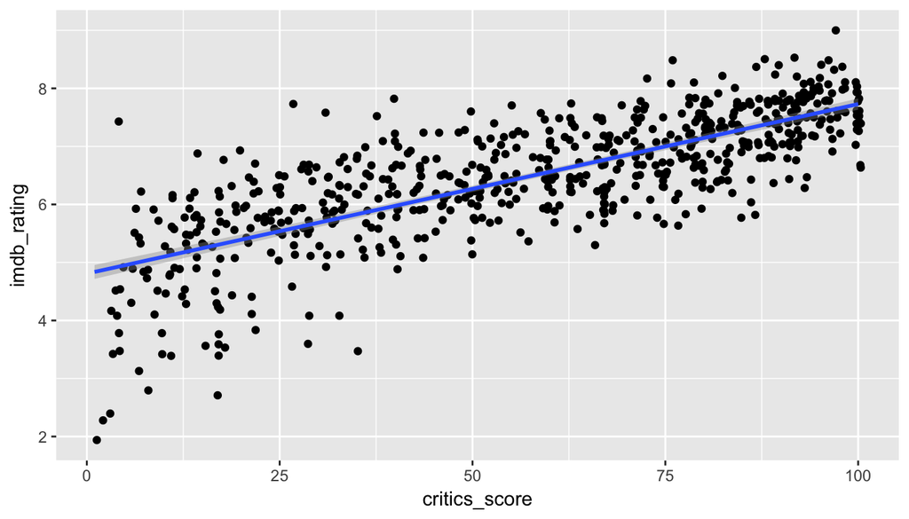

```r
ggplot(data = movies, aes(x = critics_score, y = imdb_rating)) + geom_jitter() +
  geom_smooth(method = "lm")
```

As is apparent, there is definitely a linear relationship going on here. It appears as though the critics_score is a good predictor variable for the imdb_rating variable.

Let’s set a model and interpret the slope:

```r
critics_imdb_model <-lm(imdb_rating ~ critics_score, data = movies)
summary(critics_imdb_model)
```

```
##
## Call:
## lm(formula = imdb_rating ~ critics_score, data = movies)
##
## Residuals:
##      Min       1Q   Median       3Q      Max
## -2.93679 -0.39499  0.04512  0.43875  2.47556
##
## Coefficients:
##                Estimate Std. Error t value Pr(>|t|)
## (Intercept)   4.8075715  0.0620690   77.45   <2e-16 ***
## critics_score 0.0292177  0.0009654   30.26   <2e-16 ***
## ---
## Signif. codes:  0 '***' 0.001 '**' 0.01 '*' 0.05 '.' 0.1 ' ' 1
##
## Residual standard error: 0.6991 on 649 degrees of freedom
## Multiple R-squared:  0.5853, Adjusted R-squared:  0.5846
## F-statistic: 915.9 on 1 and 649 DF,  p-value: < 2.2e-16
```

Written out, the model would be something like:

y^= β0 + β1x

or, with values, about: y^ = 4.808 + 0.029x

This means that with a Rotten tomatoes score of zero, the IMDb score would be about a 4.81, however, this is most likely an extrapolation.

the 0.029 means that for every 1 point the Rotten tomatoes critics give a given movie, the IMDb score increases by about .03

This is, however, a crude model depending only on one variable, so it would be unrealistic just to use this one variable, as there are numerous ones available.

Checking this model’s variability of residuals:

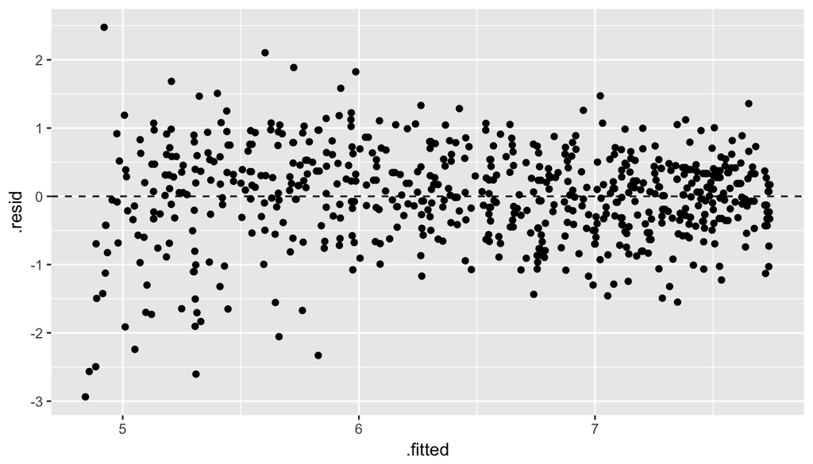

```r
ggplot(data = critics_imdb_model, aes(x = .fitted, y = .resid)) + geom_jitter() + geom_hline(yintercept = 0, linetype = "dashed")
```

Almost all of the values are between +- 1.75 or +- 2.0, with a few outliers

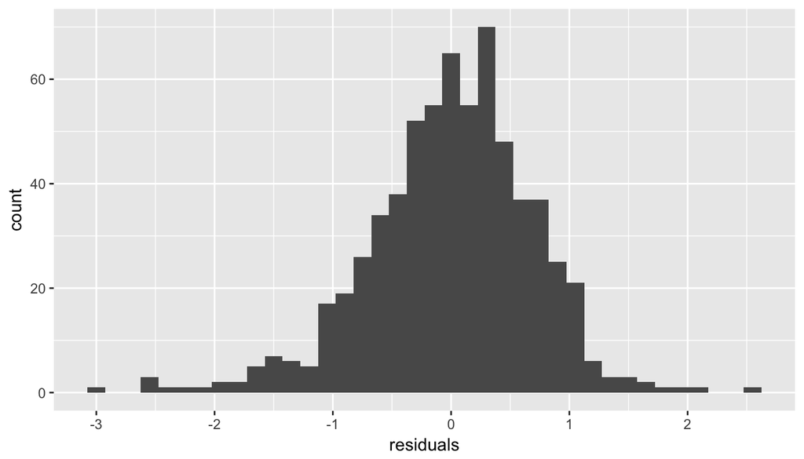

```r
ggplot(data = critics_imdb_model, aes(x = .resid)) + geom_histogram(binwidth = .15) + xlab("residuals")
```

From the plot(s), there are almost perfectly nearly normal residuals, granted with a bit of a left skew.

and, for the normal plot:

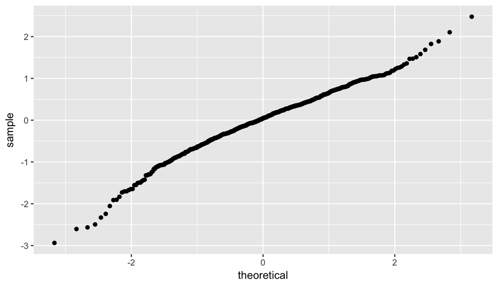

```r
ggplot(data = critics_imdb_model, aes(sample = .resid)) + stat_qq()
```

Looking quite normally distributed, all things considered.

## Part 4: Modeling

We will use backwards elimination so that we can examine the Adjusted R-squared score and evaluate it, while simultaneously considering all variables from the start.

We can immediately remove the title of the movie, anything having to do with the release dates of the DVD or film, the director, any of the five levels of actors, and the links to the websites. None of those matter. Additionally, there are too many studios and directors even to be able to print a working model to begin with.

let’s build the FULL MODEL AS THOUGH (almost) EVERYTHING MATTERED and get a summary of it. We will be using backwards elimination to reduce the model for simplicity and parsimony (occham’s razor principle).

```r
full_model <- lm(imdb_rating ~ title_type + genre + runtime + mpaa_rating + imdb_num_votes + critics_rating + critics_score +  audience_rating + audience_score + best_pic_nom + best_pic_win + best_actor_win + best_actress_win + best_dir_win + top200_box, data = movies)

summary(full_model)
```

```
##
## Call:
## lm(formula = imdb_rating ~ title_type + genre + runtime + mpaa_rating +
##     imdb_num_votes + critics_rating + critics_score + audience_rating +
##     audience_score + best_pic_nom + best_pic_win + best_actor_win +
##     best_actress_win + best_dir_win + top200_box, data = movies)
##
## Residuals:
##      Min       1Q   Median       3Q      Max
## -2.35258 -0.17932  0.02668  0.25340  1.10890
##
## Coefficients:
##                                  Estimate Std. Error t value Pr(>|t|)
## (Intercept)                     2.851e+00  2.698e-01  10.567  < 2e-16 ***
## title_typeFeature Film         -1.048e-01  1.676e-01  -0.626 0.531786
## title_typeTV Movie             -2.971e-01  2.625e-01  -1.132 0.258158
## genreAnimation                 -3.616e-01  1.762e-01  -2.053 0.040526 *
## genreArt House & International  3.358e-01  1.367e-01   2.457 0.014295 *
## genreComedy                    -1.257e-01  7.526e-02  -1.670 0.095411 .
## genreDocumentary                2.739e-01  1.794e-01   1.527 0.127291
## genreDrama                      1.031e-01  6.647e-02   1.551 0.121516
## genreHorror                     7.020e-02  1.123e-01   0.625 0.532234
## genreMusical & Performing Arts  6.892e-02  1.544e-01   0.446 0.655508
## genreMystery & Suspense         2.345e-01  8.463e-02   2.771 0.005758 **
## genreOther                     -1.324e-02  1.280e-01  -0.104 0.917598
## genreScience Fiction & Fantasy -1.590e-01  1.600e-01  -0.994 0.320699
## runtime                         3.413e-03  1.100e-03   3.102 0.002007 **
## mpaa_ratingNC-17               -1.352e-01  3.403e-01  -0.397 0.691218
## mpaa_ratingPG                  -1.331e-01  1.239e-01  -1.075 0.282914
## mpaa_ratingPG-13               -1.107e-01  1.283e-01  -0.863 0.388575
## mpaa_ratingR                   -5.669e-02  1.238e-01  -0.458 0.647270
## mpaa_ratingUnrated             -1.346e-01  1.415e-01  -0.951 0.342192
## imdb_num_votes                  9.626e-07  2.068e-07   4.654 3.99e-06 ***
## critics_ratingFresh             8.328e-02  5.640e-02   1.476 0.140320
## critics_ratingRotten            3.503e-01  9.006e-02   3.890 0.000111 ***
## critics_score                   1.478e-02  1.532e-03   9.653  < 2e-16 ***
## audience_ratingUpright         -3.447e-01  7.214e-02  -4.778 2.21e-06 ***
## audience_score                  3.974e-02  2.068e-03  19.218  < 2e-16 ***
## best_pic_nomyes                -9.122e-02  1.181e-01  -0.772 0.440162
## best_pic_winyes                -7.640e-02  2.076e-01  -0.368 0.712987
## best_actor_winyes               2.765e-02  5.345e-02   0.517 0.605164
## best_actress_winyes             5.931e-02  5.920e-02   1.002 0.316839
## best_dir_winyes                 3.901e-02  7.748e-02   0.504 0.614772
## top200_boxyes                  -9.976e-02  1.258e-01  -0.793 0.428022
## ---
## Signif. codes:  0 '***' 0.001 '**' 0.01 '*' 0.05 '.' 0.1 ' ' 1
##
## Residual standard error: 0.4467 on 619 degrees of freedom
##   (1 observation deleted due to missingness)
## Multiple R-squared:  0.8383, Adjusted R-squared:  0.8305
## F-statistic:   107 on 30 and 619 DF,  p-value: < 2.2e-16
```

```r
summary(full_model)$adj.r.squared
```

```
## [1] 0.8304692
```

We start out with an adjusted R-squared score of 0.8305, which is great, but that will undoubtedly decrease as we make legitimate, executive decisions to reduce the complexity of the model.

We would prefer a simpler model to one that is more complicated. Furthermore, not all movies have such characteristics, e.g. not all movies can win best picture.

Let’s also remove audience_rating and Critics_rating, as these are categorical variables with only two or three levels, and such categorical variables are advised against in the class.

```r
model1 <- lm(imdb_rating ~ title_type + genre + runtime + mpaa_rating + imdb_num_votes + critics_score + audience_score + best_pic_nom + best_pic_win + best_actor_win + best_actress_win + best_dir_win + top200_box, data = movies)

summary(model1)
```

```
##
## Call:
## lm(formula = imdb_rating ~ title_type + genre + runtime + mpaa_rating +
##     imdb_num_votes + critics_score + audience_score + best_pic_nom +
##     best_pic_win + best_actor_win + best_actress_win + best_dir_win +
##     top200_box, data = movies)
##
## Residuals:
##     Min      1Q  Median      3Q     Max
## -2.4280 -0.1850  0.0256  0.2574  1.1398
##
## Coefficients:
##                                  Estimate Std. Error t value Pr(>|t|)
## (Intercept)                     3.575e+00  2.462e-01  14.519  < 2e-16 ***
## title_typeFeature Film         -1.086e-01  1.726e-01  -0.630  0.52919
## title_typeTV Movie             -3.262e-01  2.704e-01  -1.207  0.22802
## genreAnimation                 -4.492e-01  1.809e-01  -2.483  0.01331 *
## genreArt House & International  2.773e-01  1.407e-01   1.971  0.04913 *
## genreComedy                    -1.279e-01  7.760e-02  -1.649  0.09972 .
## genreDocumentary                2.875e-01  1.848e-01   1.556  0.12018
## genreDrama                      9.075e-02  6.850e-02   1.325  0.18571
## genreHorror                     9.919e-02  1.158e-01   0.857  0.39184
## genreMusical & Performing Arts  8.629e-02  1.592e-01   0.542  0.58788
## genreMystery & Suspense         2.405e-01  8.699e-02   2.764  0.00587 **
## genreOther                     -3.896e-02  1.317e-01  -0.296  0.76754
## genreScience Fiction & Fantasy -2.067e-01  1.646e-01  -1.256  0.20963
## runtime                         3.910e-03  1.127e-03   3.468  0.00056 ***
## mpaa_ratingNC-17               -1.829e-01  3.504e-01  -0.522  0.60186
## mpaa_ratingPG                  -1.670e-01  1.276e-01  -1.308  0.19123
## mpaa_ratingPG-13               -1.596e-01  1.321e-01  -1.209  0.22718
## mpaa_ratingR                   -1.131e-01  1.273e-01  -0.888  0.37481
## mpaa_ratingUnrated             -1.863e-01  1.457e-01  -1.279  0.20149
## imdb_num_votes                  8.923e-07  2.034e-07   4.387 1.35e-05 ***
## critics_score                   1.019e-02  9.580e-04  10.639  < 2e-16 ***
## audience_score                  3.240e-02  1.361e-03  23.799  < 2e-16 ***
## best_pic_nomyes                -8.545e-02  1.213e-01  -0.705  0.48134
## best_pic_winyes                -9.925e-02  2.139e-01  -0.464  0.64280
## best_actor_winyes               4.139e-02  5.503e-02   0.752  0.45225
## best_actress_winyes             6.157e-02  6.093e-02   1.011  0.31260
## best_dir_winyes                 4.888e-02  7.973e-02   0.613  0.54009
## top200_boxyes                  -1.436e-01  1.293e-01  -1.111  0.26717
## ---
## Signif. codes:  0 '***' 0.001 '**' 0.01 '*' 0.05 '.' 0.1 ' ' 1
##
## Residual standard error: 0.4607 on 622 degrees of freedom
##   (1 observation deleted due to missingness)
## Multiple R-squared:  0.8272, Adjusted R-squared:  0.8197
## F-statistic: 110.3 on 27 and 622 DF,  p-value: < 2.2e-16
```

```r
summary(model1)$adj.r.squared
```

```
## [1] 0.8196953
```

So we have gone from .8305 to .8197, a drop, yes, but a justifiable one.

Let’s remove title_type as well, as this categorical variable has only three levels as well:

```r
model2 <- lm(imdb_rating ~ genre + runtime + mpaa_rating + imdb_num_votes + critics_score + audience_score + best_pic_nom + best_pic_win + best_actor_win + best_actress_win + best_dir_win + top200_box, data = movies)

summary(model2)
```

```
##
## Call:
## lm(formula = imdb_rating ~ genre + runtime + mpaa_rating + imdb_num_votes +
##     critics_score + audience_score + best_pic_nom + best_pic_win +
##     best_actor_win + best_actress_win + best_dir_win + top200_box,
##     data = movies)
##
## Residuals:
##      Min       1Q   Median       3Q      Max
## -2.42233 -0.18481  0.02212  0.25497  1.14330
##
## Coefficients:
##                                  Estimate Std. Error t value Pr(>|t|)
## (Intercept)                     3.458e+00  1.735e-01  19.936  < 2e-16 ***
## genreAnimation                 -4.497e-01  1.809e-01  -2.487 0.013152 *
## genreArt House & International  2.792e-01  1.404e-01   1.988 0.047209 *
## genreComedy                    -1.249e-01  7.748e-02  -1.613 0.107340
## genreDocumentary                3.902e-01  1.072e-01   3.639 0.000296 ***
## genreDrama                      8.689e-02  6.839e-02   1.271 0.204368
## genreHorror                     1.016e-01  1.156e-01   0.879 0.379870
## genreMusical & Performing Arts  1.205e-01  1.505e-01   0.800 0.423734
## genreMystery & Suspense         2.404e-01  8.695e-02   2.765 0.005854 **
## genreOther                     -5.423e-02  1.310e-01  -0.414 0.679035
## genreScience Fiction & Fantasy -2.065e-01  1.645e-01  -1.255 0.209900
## runtime                         3.941e-03  1.127e-03   3.498 0.000502 ***
## mpaa_ratingNC-17               -1.824e-01  3.502e-01  -0.521 0.602737
## mpaa_ratingPG                  -1.658e-01  1.276e-01  -1.299 0.194297
## mpaa_ratingPG-13               -1.586e-01  1.320e-01  -1.202 0.229963
## mpaa_ratingR                   -1.144e-01  1.273e-01  -0.899 0.368905
## mpaa_ratingUnrated             -1.934e-01  1.448e-01  -1.336 0.182138
## imdb_num_votes                  8.921e-07  2.031e-07   4.393 1.31e-05 ***
## critics_score                   1.025e-02  9.507e-04  10.784  < 2e-16 ***
## audience_score                  3.245e-02  1.360e-03  23.858  < 2e-16 ***
## best_pic_nomyes                -8.489e-02  1.212e-01  -0.700 0.483991
## best_pic_winyes                -1.007e-01  2.138e-01  -0.471 0.637625
## best_actor_winyes               4.272e-02  5.498e-02   0.777 0.437489
## best_actress_winyes             5.943e-02  6.087e-02   0.976 0.329303
## best_dir_winyes                 4.799e-02  7.965e-02   0.603 0.547025
## top200_boxyes                  -1.448e-01  1.293e-01  -1.120 0.263142
## ---
## Signif. codes:  0 '***' 0.001 '**' 0.01 '*' 0.05 '.' 0.1 ' ' 1
##
## Residual standard error: 0.4605 on 624 degrees of freedom
##   (1 observation deleted due to missingness)
## Multiple R-squared:  0.8268, Adjusted R-squared:  0.8198
## F-statistic: 119.1 on 25 and 624 DF,  p-value: < 2.2e-16
```

```r
summary(model2)$adj.r.squared
```

```
## [1] 0.8198458
```

From .8197 to .8198, an increase, so this is a good move on our part. Next, let’s try removing: top_200box

```r
model3 <- lm(imdb_rating ~ genre + runtime + mpaa_rating + imdb_num_votes + critics_score + audience_score + best_pic_nom + best_pic_win + best_actor_win + best_actress_win + best_dir_win, data = movies)

summary(model3)
```

```
##
## Call:
## lm(formula = imdb_rating ~ genre + runtime + mpaa_rating + imdb_num_votes +
##     critics_score + audience_score + best_pic_nom + best_pic_win +
##     best_actor_win + best_actress_win + best_dir_win, data = movies)
##
## Residuals:
##      Min       1Q   Median       3Q      Max
## -2.41764 -0.17993  0.02331  0.25964  1.14676
##
## Coefficients:
##                                  Estimate Std. Error t value Pr(>|t|)
## (Intercept)                     3.445e+00  1.731e-01  19.903  < 2e-16 ***
## genreAnimation                 -4.295e-01  1.800e-01  -2.386 0.017310 *
## genreArt House & International  2.842e-01  1.404e-01   2.024 0.043410 *
## genreComedy                    -1.190e-01  7.731e-02  -1.539 0.124324
## genreDocumentary                3.982e-01  1.070e-01   3.721 0.000217 ***
## genreDrama                      9.338e-02  6.816e-02   1.370 0.171177
## genreHorror                     1.060e-01  1.156e-01   0.917 0.359440
## genreMusical & Performing Arts  1.286e-01  1.503e-01   0.856 0.392571
## genreMystery & Suspense         2.477e-01  8.672e-02   2.857 0.004421 **
## genreOther                     -4.911e-02  1.309e-01  -0.375 0.707769
## genreScience Fiction & Fantasy -2.106e-01  1.645e-01  -1.280 0.200883
## runtime                         3.879e-03  1.125e-03   3.446 0.000606 ***
## mpaa_ratingNC-17               -1.645e-01  3.499e-01  -0.470 0.638334
## mpaa_ratingPG                  -1.544e-01  1.272e-01  -1.214 0.225355
## mpaa_ratingPG-13               -1.420e-01  1.312e-01  -1.082 0.279505
## mpaa_ratingR                   -9.591e-02  1.262e-01  -0.760 0.447530
## mpaa_ratingUnrated             -1.772e-01  1.441e-01  -1.230 0.219210
## imdb_num_votes                  8.386e-07  1.974e-07   4.248 2.49e-05 ***
## critics_score                   1.020e-02  9.498e-04  10.739  < 2e-16 ***
## audience_score                  3.247e-02  1.360e-03  23.871  < 2e-16 ***
## best_pic_nomyes                -8.108e-02  1.212e-01  -0.669 0.503718
## best_pic_winyes                -1.003e-01  2.138e-01  -0.469 0.639282
## best_actor_winyes               4.123e-02  5.498e-02   0.750 0.453612
## best_actress_winyes             5.602e-02  6.081e-02   0.921 0.357253
## best_dir_winyes                 5.054e-02  7.963e-02   0.635 0.525876
## ---
## Signif. codes:  0 '***' 0.001 '**' 0.01 '*' 0.05 '.' 0.1 ' ' 1
##
## Residual standard error: 0.4606 on 625 degrees of freedom
##   (1 observation deleted due to missingness)
## Multiple R-squared:  0.8264, Adjusted R-squared:  0.8198
## F-statistic:   124 on 24 and 625 DF,  p-value: < 2.2e-16
```

```r
summary(model3)$adj.r.squared
```

```
## [1] 0.8197724
```

No change at all, so a variable out without any change is good. The variable could be colinnear.

Next let’s try taking out best_pic_win, as this is, of course, very rare.

```r
model4 <- lm(imdb_rating ~ genre + runtime + mpaa_rating + imdb_num_votes + critics_score + audience_score + best_pic_nom + best_actor_win + best_actress_win + best_dir_win, data = movies)

summary(model4)
```

```
##
## Call:
## lm(formula = imdb_rating ~ genre + runtime + mpaa_rating + imdb_num_votes +
##     critics_score + audience_score + best_pic_nom + best_actor_win +
##     best_actress_win + best_dir_win, data = movies)
##
## Residuals:
##      Min       1Q   Median       3Q      Max
## -2.41724 -0.17945  0.02703  0.25912  1.14658
##
## Coefficients:
##                                  Estimate Std. Error t value Pr(>|t|)
## (Intercept)                     3.444e+00  1.730e-01  19.913  < 2e-16 ***
## genreAnimation                 -4.299e-01  1.799e-01  -2.390 0.017156 *
## genreArt House & International  2.824e-01  1.403e-01   2.013 0.044500 *
## genreComedy                    -1.207e-01  7.717e-02  -1.564 0.118336
## genreDocumentary                3.959e-01  1.068e-01   3.706 0.000229 ***
## genreDrama                      9.245e-02  6.809e-02   1.358 0.175041
## genreHorror                     1.054e-01  1.155e-01   0.912 0.361919
## genreMusical & Performing Arts  1.273e-01  1.502e-01   0.847 0.397191
## genreMystery & Suspense         2.469e-01  8.665e-02   2.849 0.004525 **
## genreOther                     -4.570e-02  1.307e-01  -0.350 0.726618
## genreScience Fiction & Fantasy -2.095e-01  1.644e-01  -1.275 0.202931
## runtime                         3.872e-03  1.125e-03   3.443 0.000613 ***
## mpaa_ratingNC-17               -1.656e-01  3.497e-01  -0.474 0.636002
## mpaa_ratingPG                  -1.542e-01  1.271e-01  -1.213 0.225436
## mpaa_ratingPG-13               -1.397e-01  1.310e-01  -1.067 0.286562
## mpaa_ratingR                   -9.477e-02  1.261e-01  -0.752 0.452609
## mpaa_ratingUnrated             -1.771e-01  1.440e-01  -1.230 0.219140
## imdb_num_votes                  8.216e-07  1.940e-07   4.236 2.62e-05 ***
## critics_score                   1.020e-02  9.492e-04  10.748  < 2e-16 ***
## audience_score                  3.250e-02  1.357e-03  23.947  < 2e-16 ***
## best_pic_nomyes                -1.040e-01  1.108e-01  -0.938 0.348617
## best_actor_winyes               4.317e-02  5.478e-02   0.788 0.430963
## best_actress_winyes             5.466e-02  6.070e-02   0.901 0.368180
## best_dir_winyes                 4.021e-02  7.647e-02   0.526 0.599217
## ---
## Signif. codes:  0 '***' 0.001 '**' 0.01 '*' 0.05 '.' 0.1 ' ' 1
##
## Residual standard error: 0.4603 on 626 degrees of freedom
##   (1 observation deleted due to missingness)
## Multiple R-squared:  0.8264, Adjusted R-squared:   0.82
## F-statistic: 129.5 on 23 and 626 DF,  p-value: < 2.2e-16
```

```r
summary(model4)$adj.r.squared
```

```
## [1] 0.819997
```

From .8198 to .82, an increase! This seemed like a justified move as well.

For our next removal, let’s take away best_dir_win:

```r
model5 <- lm(imdb_rating ~ genre + runtime + mpaa_rating + imdb_num_votes + critics_score + audience_score + best_pic_nom + best_actor_win + best_actress_win, data = movies)

summary(model5)
```

```
##
## Call:
## lm(formula = imdb_rating ~ genre + runtime + mpaa_rating + imdb_num_votes +
##     critics_score + audience_score + best_pic_nom + best_actor_win +
##     best_actress_win, data = movies)
##
## Residuals:
##      Min       1Q   Median       3Q      Max
## -2.41682 -0.18020  0.02411  0.25764  1.14545
##
## Coefficients:
##                                  Estimate Std. Error t value Pr(>|t|)
## (Intercept)                     3.433e+00  1.717e-01  19.999  < 2e-16 ***
## genreAnimation                 -4.302e-01  1.798e-01  -2.393 0.017005 *
## genreArt House & International  2.808e-01  1.401e-01   2.004 0.045552 *
## genreComedy                    -1.205e-01  7.713e-02  -1.562 0.118825
## genreDocumentary                3.944e-01  1.067e-01   3.695 0.000239 ***
## genreDrama                      9.164e-02  6.803e-02   1.347 0.178444
## genreHorror                     1.059e-01  1.155e-01   0.917 0.359309
## genreMusical & Performing Arts  1.265e-01  1.501e-01   0.843 0.399782
## genreMystery & Suspense         2.469e-01  8.660e-02   2.851 0.004502 **
## genreOther                     -4.820e-02  1.305e-01  -0.369 0.711962
## genreScience Fiction & Fantasy -2.078e-01  1.643e-01  -1.265 0.206400
## runtime                         3.969e-03  1.109e-03   3.578 0.000372 ***
## mpaa_ratingNC-17               -1.671e-01  3.495e-01  -0.478 0.632652
## mpaa_ratingPG                  -1.522e-01  1.270e-01  -1.199 0.231011
## mpaa_ratingPG-13               -1.391e-01  1.309e-01  -1.062 0.288438
## mpaa_ratingR                   -9.312e-02  1.260e-01  -0.739 0.460108
## mpaa_ratingUnrated             -1.779e-01  1.439e-01  -1.236 0.216855
## imdb_num_votes                  8.286e-07  1.934e-07   4.285 2.12e-05 ***
## critics_score                   1.025e-02  9.446e-04  10.849  < 2e-16 ***
## audience_score                  3.249e-02  1.356e-03  23.955  < 2e-16 ***
## best_pic_nomyes                -1.009e-01  1.106e-01  -0.912 0.362097
## best_actor_winyes               4.397e-02  5.473e-02   0.803 0.422100
## best_actress_winyes             5.506e-02  6.066e-02   0.908 0.364387
## ---
## Signif. codes:  0 '***' 0.001 '**' 0.01 '*' 0.05 '.' 0.1 ' ' 1
##
## Residual standard error: 0.46 on 627 degrees of freedom
##   (1 observation deleted due to missingness)
## Multiple R-squared:  0.8263, Adjusted R-squared:  0.8202
## F-statistic: 135.6 on 22 and 627 DF,  p-value: < 2.2e-16
```

```r
summary(model5)$adj.r.squared
```

```
## [1] 0.8202047
```

From .82 to .8202 an insignificant increase for the sake of parsimony.

Next, let’s remove best_actor_win:

```r
model6 <- lm(imdb_rating ~ genre + runtime + mpaa_rating + imdb_num_votes + critics_score + audience_score + best_pic_nom + best_actress_win, data = movies)

summary(model6)
```

```
##
## Call:
## lm(formula = imdb_rating ~ genre + runtime + mpaa_rating + imdb_num_votes +
##     critics_score + audience_score + best_pic_nom + best_actress_win,
##     data = movies)
##
## Residuals:
##      Min       1Q   Median       3Q      Max
## -2.41763 -0.18326  0.03194  0.25670  1.13928
##
## Coefficients:
##                                  Estimate Std. Error t value Pr(>|t|)
## (Intercept)                     3.420e+00  1.708e-01  20.021  < 2e-16 ***
## genreAnimation                 -4.272e-01  1.797e-01  -2.377 0.017736 *
## genreArt House & International  2.772e-01  1.400e-01   1.980 0.048175 *
## genreComedy                    -1.204e-01  7.711e-02  -1.561 0.118924
## genreDocumentary                3.942e-01  1.067e-01   3.694 0.000240 ***
## genreDrama                      9.311e-02  6.799e-02   1.369 0.171356
## genreHorror                     1.036e-01  1.154e-01   0.898 0.369775
## genreMusical & Performing Arts  1.243e-01  1.501e-01   0.828 0.407980
## genreMystery & Suspense         2.528e-01  8.626e-02   2.931 0.003503 **
## genreOther                     -4.723e-02  1.305e-01  -0.362 0.717451
## genreScience Fiction & Fantasy -2.121e-01  1.641e-01  -1.292 0.196664
## runtime                         4.146e-03  1.087e-03   3.815 0.000149 ***
## mpaa_ratingNC-17               -1.501e-01  3.487e-01  -0.431 0.666938
## mpaa_ratingPG                  -1.494e-01  1.269e-01  -1.177 0.239559
## mpaa_ratingPG-13               -1.385e-01  1.309e-01  -1.058 0.290447
## mpaa_ratingR                   -9.289e-02  1.259e-01  -0.737 0.461096
## mpaa_ratingUnrated             -1.797e-01  1.439e-01  -1.249 0.212073
## imdb_num_votes                  8.231e-07  1.932e-07   4.260 2.36e-05 ***
## critics_score                   1.026e-02  9.441e-04  10.868  < 2e-16 ***
## audience_score                  3.246e-02  1.355e-03  23.948  < 2e-16 ***
## best_pic_nomyes                -9.231e-02  1.101e-01  -0.839 0.402020
## best_actress_winyes             5.760e-02  6.056e-02   0.951 0.341877
## ---
## Signif. codes:  0 '***' 0.001 '**' 0.01 '*' 0.05 '.' 0.1 ' ' 1
##
## Residual standard error: 0.4599 on 628 degrees of freedom
##   (1 observation deleted due to missingness)
## Multiple R-squared:  0.8261, Adjusted R-squared:  0.8203
## F-statistic: 142.1 on 21 and 628 DF,  p-value: < 2.2e-16
```

```r
summary(model6)$adj.r.squared
```

```
## [1] 0.8203063
```

From .8202 to .8203 an increase, so we are doing the right thing.

Let’s then remove best_pic_nom:

```r
model7 <- lm(imdb_rating ~ genre + runtime + mpaa_rating + imdb_num_votes + critics_score + audience_score + best_actor_win + best_actress_win, data = movies)

summary(model7)
```

```
##
## Call:
## lm(formula = imdb_rating ~ genre + runtime + mpaa_rating + imdb_num_votes +
##     critics_score + audience_score + best_actor_win + best_actress_win,
##     data = movies)
##
## Residuals:
##      Min       1Q   Median       3Q      Max
## -2.42351 -0.18293  0.02569  0.26019  1.14796
##
## Coefficients:
##                                  Estimate Std. Error t value Pr(>|t|)
## (Intercept)                     3.454e+00  1.702e-01  20.299  < 2e-16 ***
## genreAnimation                 -4.307e-01  1.797e-01  -2.396 0.016848 *
## genreArt House & International  2.781e-01  1.401e-01   1.985 0.047614 *
## genreComedy                    -1.232e-01  7.706e-02  -1.598 0.110499
## genreDocumentary                3.934e-01  1.067e-01   3.686 0.000247 ***
## genreDrama                      8.893e-02  6.796e-02   1.309 0.191162
## genreHorror                     1.009e-01  1.153e-01   0.875 0.382030
## genreMusical & Performing Arts  1.284e-01  1.501e-01   0.856 0.392548
## genreMystery & Suspense         2.463e-01  8.658e-02   2.845 0.004585 **
## genreOther                     -5.516e-02  1.303e-01  -0.423 0.672096
## genreScience Fiction & Fantasy -2.082e-01  1.642e-01  -1.268 0.205256
## runtime                         3.865e-03  1.103e-03   3.504 0.000491 ***
## mpaa_ratingNC-17               -1.632e-01  3.494e-01  -0.467 0.640542
## mpaa_ratingPG                  -1.539e-01  1.269e-01  -1.213 0.225737
## mpaa_ratingPG-13               -1.394e-01  1.309e-01  -1.065 0.287325
## mpaa_ratingR                   -9.265e-02  1.260e-01  -0.736 0.462287
## mpaa_ratingUnrated             -1.756e-01  1.439e-01  -1.221 0.222603
## imdb_num_votes                  7.922e-07  1.892e-07   4.187 3.23e-05 ***
## critics_score                   1.020e-02  9.431e-04  10.818  < 2e-16 ***
## audience_score                  3.241e-02  1.353e-03  23.948  < 2e-16 ***
## best_actor_winyes               3.914e-02  5.447e-02   0.719 0.472626
## best_actress_winyes             4.774e-02  6.012e-02   0.794 0.427417
## ---
## Signif. codes:  0 '***' 0.001 '**' 0.01 '*' 0.05 '.' 0.1 ' ' 1
##
## Residual standard error: 0.4599 on 628 degrees of freedom
##   (1 observation deleted due to missingness)
## Multiple R-squared:  0.8261, Adjusted R-squared:  0.8203
## F-statistic:   142 on 21 and 628 DF,  p-value: < 2.2e-16
```

```r
summary(model7)$adj.r.squared
```

```
## [1] 0.8202529
```

Again, no change, .8203, so perhaps some collinearity again.

Now, let’s remove best_actor_win:

```r
model8 <- lm(imdb_rating ~ genre + runtime + mpaa_rating + imdb_num_votes + critics_score + audience_score + best_actress_win, data = movies)

summary(model8)
```

```
##
## Call:
## lm(formula = imdb_rating ~ genre + runtime + mpaa_rating + imdb_num_votes +
##     critics_score + audience_score + best_actress_win, data = movies)
##
## Residuals:
##      Min       1Q   Median       3Q      Max
## -2.42373 -0.18207  0.02399  0.25433  1.14222
##
## Coefficients:
##                                  Estimate Std. Error t value Pr(>|t|)
## (Intercept)                     3.440e+00  1.690e-01  20.353  < 2e-16 ***
## genreAnimation                 -4.280e-01  1.796e-01  -2.382 0.017492 *
## genreArt House & International  2.751e-01  1.400e-01   1.965 0.049854 *
## genreComedy                    -1.229e-01  7.703e-02  -1.595 0.111128
## genreDocumentary                3.933e-01  1.067e-01   3.687 0.000247 ***
## genreDrama                      9.045e-02  6.790e-02   1.332 0.183310
## genreHorror                     9.914e-02  1.152e-01   0.860 0.389940
## genreMusical & Performing Arts  1.263e-01  1.500e-01   0.842 0.400295
## genreMystery & Suspense         2.517e-01  8.623e-02   2.919 0.003637 **
## genreOther                     -5.375e-02  1.302e-01  -0.413 0.679849
## genreScience Fiction & Fantasy -2.121e-01  1.641e-01  -1.293 0.196525
## runtime                         4.032e-03  1.078e-03   3.741 0.000200 ***
## mpaa_ratingNC-17               -1.483e-01  3.486e-01  -0.425 0.670786
## mpaa_ratingPG                  -1.512e-01  1.268e-01  -1.192 0.233583
## mpaa_ratingPG-13               -1.388e-01  1.309e-01  -1.061 0.289141
## mpaa_ratingR                   -9.248e-02  1.259e-01  -0.734 0.462948
## mpaa_ratingUnrated             -1.774e-01  1.438e-01  -1.234 0.217695
## imdb_num_votes                  7.900e-07  1.891e-07   4.177 3.36e-05 ***
## critics_score                   1.022e-02  9.425e-04  10.841  < 2e-16 ***
## audience_score                  3.239e-02  1.353e-03  23.947  < 2e-16 ***
## best_actress_winyes             5.059e-02  5.996e-02   0.844 0.399206
## ---
## Signif. codes:  0 '***' 0.001 '**' 0.01 '*' 0.05 '.' 0.1 ' ' 1
##
## Residual standard error: 0.4598 on 629 degrees of freedom
##   (1 observation deleted due to missingness)
## Multiple R-squared:  0.8259, Adjusted R-squared:  0.8204
## F-statistic: 149.2 on 20 and 629 DF,  p-value: < 2.2e-16
```

```r
summary(model8)$adj.r.squared
```

```
## [1] 0.8203911
```

An increase, so maybe some collinearity again.

Let’s try removing: best_actress_win

```r
model9 <- lm(imdb_rating ~ genre + runtime + mpaa_rating + imdb_num_votes + critics_score + audience_score, data = movies)

summary(model9)
```

```
##
## Call:
## lm(formula = imdb_rating ~ genre + runtime + mpaa_rating + imdb_num_votes +
##     critics_score + audience_score, data = movies)
##
## Residuals:
##      Min       1Q   Median       3Q      Max
## -2.41990 -0.18152  0.02739  0.25934  1.13339
##
## Coefficients:
##                                  Estimate Std. Error t value Pr(>|t|)
## (Intercept)                     3.427e+00  1.683e-01  20.366  < 2e-16 ***
## genreAnimation                 -4.203e-01  1.794e-01  -2.343 0.019424 *
## genreArt House & International  2.810e-01  1.398e-01   2.010 0.044806 *
## genreComedy                    -1.164e-01  7.662e-02  -1.519 0.129366
## genreDocumentary                3.971e-01  1.066e-01   3.727 0.000212 ***
## genreDrama                      9.819e-02  6.726e-02   1.460 0.144852
## genreHorror                     1.019e-01  1.152e-01   0.885 0.376475
## genreMusical & Performing Arts  1.263e-01  1.500e-01   0.842 0.400046
## genreMystery & Suspense         2.599e-01  8.565e-02   3.035 0.002506 **
## genreOther                     -4.885e-02  1.300e-01  -0.376 0.707285
## genreScience Fiction & Fantasy -2.121e-01  1.640e-01  -1.293 0.196516
## runtime                         4.166e-03  1.066e-03   3.908 0.000103 ***
## mpaa_ratingNC-17               -1.561e-01  3.484e-01  -0.448 0.654374
## mpaa_ratingPG                  -1.504e-01  1.268e-01  -1.186 0.236199
## mpaa_ratingPG-13               -1.386e-01  1.308e-01  -1.060 0.289732
## mpaa_ratingR                   -9.411e-02  1.259e-01  -0.748 0.454970
## mpaa_ratingUnrated             -1.797e-01  1.437e-01  -1.250 0.211773
## imdb_num_votes                  7.993e-07  1.887e-07   4.235 2.62e-05 ***
## critics_score                   1.025e-02  9.413e-04  10.894  < 2e-16 ***
## audience_score                  3.234e-02  1.351e-03  23.939  < 2e-16 ***
## ---
## Signif. codes:  0 '***' 0.001 '**' 0.01 '*' 0.05 '.' 0.1 ' ' 1
##
## Residual standard error: 0.4597 on 630 degrees of freedom
##   (1 observation deleted due to missingness)
## Multiple R-squared:  0.8257, Adjusted R-squared:  0.8205
## F-statistic: 157.1 on 19 and 630 DF,  p-value: < 2.2e-16
```

```r
summary(model9)$adj.r.squared
```

```
## [1] 0.8204733
```

.8205, an increase by .0001 …. probably due to collinearity, but definitely a good move.

Next, let’s try Removing IMDb votes:

```r
model10 <- lm(imdb_rating ~ genre + runtime + mpaa_rating + critics_score + audience_score, data = movies)

summary(model10)
```

```
##
## Call:
## lm(formula = imdb_rating ~ genre + runtime + mpaa_rating + critics_score +
##     audience_score, data = movies)
##
## Residuals:
##      Min       1Q   Median       3Q      Max
## -2.35145 -0.19673  0.03303  0.27517  1.18280
##
## Coefficients:
##                                  Estimate Std. Error t value Pr(>|t|)
## (Intercept)                     3.2572102  0.1656028  19.669  < 2e-16 ***
## genreAnimation                 -0.4156054  0.1817503  -2.287  0.02254 *
## genreArt House & International  0.2161483  0.1407845   1.535  0.12521
## genreComedy                    -0.1381724  0.0774679  -1.784  0.07497 .
## genreDocumentary                0.3163532  0.1062388   2.978  0.00302 **
## genreDrama                      0.0505158  0.0671969   0.752  0.45248
## genreHorror                     0.0853292  0.1166313   0.732  0.46468
## genreMusical & Performing Arts  0.0296336  0.1502059   0.197  0.84367
## genreMystery & Suspense         0.2407351  0.0866712   2.778  0.00564 **
## genreOther                     -0.0431647  0.1317577  -0.328  0.74332
## genreScience Fiction & Fantasy -0.1985049  0.1661948  -1.194  0.23277
## runtime                         0.0054142  0.0010381   5.216 2.49e-07 ***
## mpaa_ratingNC-17               -0.1655426  0.3530793  -0.469  0.63934
## mpaa_ratingPG                  -0.1514550  0.1284987  -1.179  0.23898
## mpaa_ratingPG-13               -0.1030216  0.1322912  -0.779  0.43642
## mpaa_ratingR                   -0.0720141  0.1274442  -0.565  0.57223
## mpaa_ratingUnrated             -0.1990438  0.1455781  -1.367  0.17203
## critics_score                   0.0104979  0.0009521  11.026  < 2e-16 ***
## audience_score                  0.0337807  0.0013243  25.508  < 2e-16 ***
## ---
## Signif. codes:  0 '***' 0.001 '**' 0.01 '*' 0.05 '.' 0.1 ' ' 1
##
## Residual standard error: 0.4658 on 631 degrees of freedom
##   (1 observation deleted due to missingness)
## Multiple R-squared:  0.8208, Adjusted R-squared:  0.8157
## F-statistic: 160.5 on 18 and 631 DF,  p-value: < 2.2e-16
```

```r
summary(model10)$adj.r.squared
```

```
## [1] 0.8156545
```

The adjusted score went from .8204 to .8157

So there was a drop of the Adjusted R-Square score of about.0047 … Although normally we don’t want drops in our adjusted R-squared score, I believe that this is justified because otherwise, the argument is circular in that it would be using IMDb votes to determine the IMDb score, and we are trying to determine the IMDb score from the Rotten Tomatoes score. And anyway, only .0047 was lost, which doesn’t do much for the final adjusted R-squared score.

We have gone from .8304 to .8157 and have eliminated numerous variables. Not to bad!

Interpretation of model coefficients:

The model coefficients determine how things change or to what degree things change “all else held constant.” For example, “all else held constant,” an mpaa R rated movie would reduce the score of the movie by about .07, as opposed to an mpaa “unrated” movie, which would reduce the score, supposedly, by about .2

Another example is that a Science fiction and fantasy-genre movie would reduce the score by about .2, whereas an art house and international-genre movie would increase the score by about .216, “all else held constant.”

This leads us to our prediction_model, the one we will use for the prediction of an IMDb rating.

Model Diagnostics:

```r
prediction_model <- lm(imdb_rating ~ genre + runtime + mpaa_rating + critics_score + audience_score, data = movies)

summary(prediction_model)
```

```
##
## Call:
## lm(formula = imdb_rating ~ genre + runtime + mpaa_rating + critics_score +
##     audience_score, data = movies)
##
## Residuals:
##      Min       1Q   Median       3Q      Max
## -2.35145 -0.19673  0.03303  0.27517  1.18280
##
## Coefficients:
##                                  Estimate Std. Error t value Pr(>|t|)
## (Intercept)                     3.2572102  0.1656028  19.669  < 2e-16 ***
## genreAnimation                 -0.4156054  0.1817503  -2.287  0.02254 *
## genreArt House & International  0.2161483  0.1407845   1.535  0.12521
## genreComedy                    -0.1381724  0.0774679  -1.784  0.07497 .
## genreDocumentary                0.3163532  0.1062388   2.978  0.00302 **
## genreDrama                      0.0505158  0.0671969   0.752  0.45248
## genreHorror                     0.0853292  0.1166313   0.732  0.46468
## genreMusical & Performing Arts  0.0296336  0.1502059   0.197  0.84367
## genreMystery & Suspense         0.2407351  0.0866712   2.778  0.00564 **
## genreOther                     -0.0431647  0.1317577  -0.328  0.74332
## genreScience Fiction & Fantasy -0.1985049  0.1661948  -1.194  0.23277
## runtime                         0.0054142  0.0010381   5.216 2.49e-07 ***
## mpaa_ratingNC-17               -0.1655426  0.3530793  -0.469  0.63934
## mpaa_ratingPG                  -0.1514550  0.1284987  -1.179  0.23898
## mpaa_ratingPG-13               -0.1030216  0.1322912  -0.779  0.43642
## mpaa_ratingR                   -0.0720141  0.1274442  -0.565  0.57223
## mpaa_ratingUnrated             -0.1990438  0.1455781  -1.367  0.17203
## critics_score                   0.0104979  0.0009521  11.026  < 2e-16 ***
## audience_score                  0.0337807  0.0013243  25.508  < 2e-16 ***
## ---
## Signif. codes:  0 '***' 0.001 '**' 0.01 '*' 0.05 '.' 0.1 ' ' 1
##
## Residual standard error: 0.4658 on 631 degrees of freedom
##   (1 observation deleted due to missingness)
## Multiple R-squared:  0.8208, Adjusted R-squared:  0.8157
## F-statistic: 160.5 on 18 and 631 DF,  p-value: < 2.2e-16
```

```r
summary(prediction_model)$adj.r.squared
```

```
## [1] 0.8156545
```

There is obviously constant variability so,

Linearity

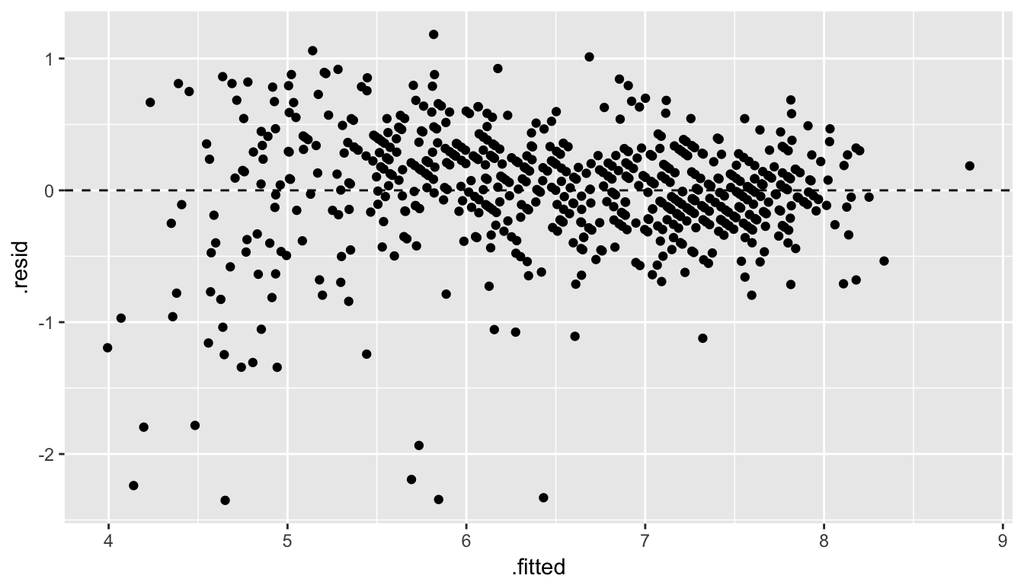

```r
ggplot(data = prediction_model, aes(x = .fitted, y = .resid)) + geom_jitter() + geom_hline(yintercept = 0, linetype = "dashed")
```

Halfway decent, as most values are within +- 1.5, and without the outliers in the lower left, there really isn’t a fan shape at all

Nearly normal residuals

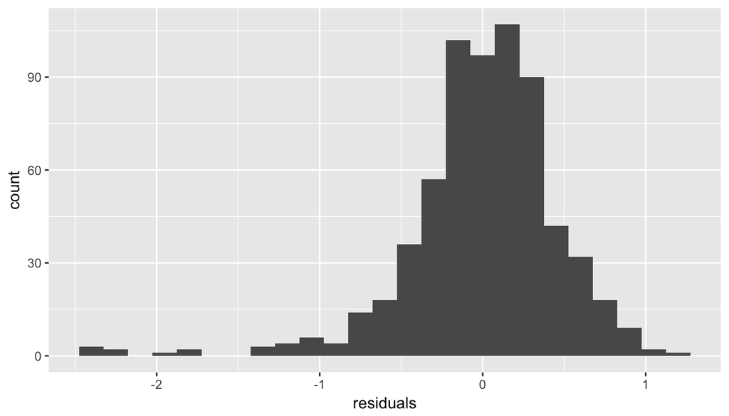

```r
ggplot(data = prediction_model, aes(x = .resid)) + geom_histogram(binwidth = .15) + xlab("residuals")
```

A bit of a left skew, but not too bad–a natural shortcoming of a model, always imperfect.

normal line plot:

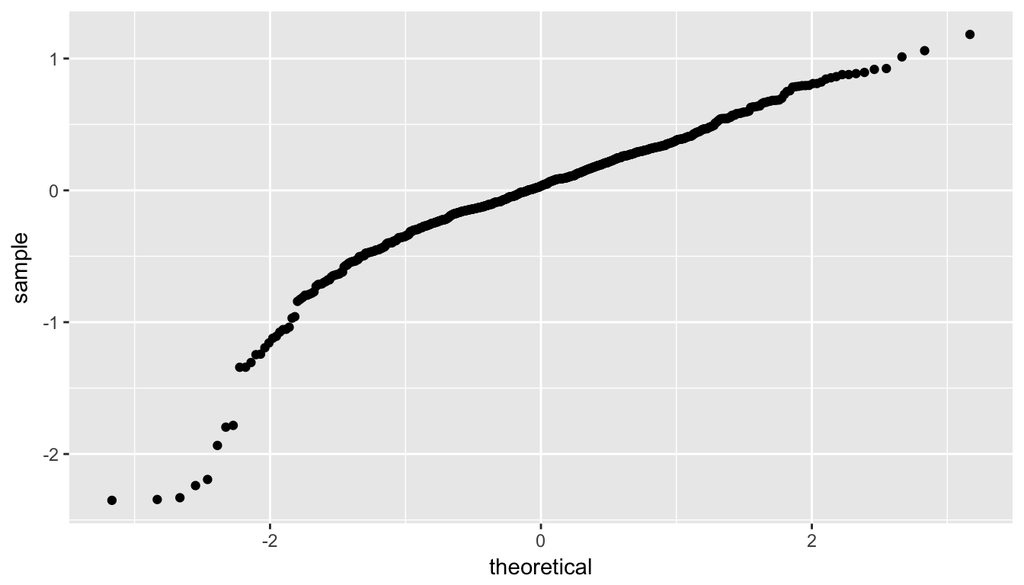

```r
ggplot(data = prediction_model, aes(sample = .resid)) + stat_qq()
```

Could be worse I suppose… a natural shortcoming of any model, again.

I suppose our model is decent, but it could always be so bad as to be unusable, which it’s not! * * *

## Part 5: Prediction

To estimate, let’s use “Rogue One”, a movie in the Star Wars franchise series:

http://www.imdb.com/title/tt3748528/?ref_=nv_sr_8 https://www.rottentomatoes.com/m/rogue_one_a_star_wars_story

```r
rogueone <- data.frame(genre = "Action & Adventure",  runtime = 133, mpaa_rating = "PG-13", critics_score = 85, audience_score = 88)

predict(prediction_model, rogueone, interval = "prediction", level = 0.95)
```

```
##        fit      lwr      upr
## 1 7.739295 6.810615 8.667976
```

Rogue One is rated at 8.1 on the IMDb movie scale. The model predicts, with 95% confidence, that a movie with the above attributes will have an IMDb score between about 6.8 and 8.7 Rogue one’s IMDb rating does indeed fall within this range. Not too bad a prediction, comparing its 8.1 to the fitted 7.7 or so.

## Part 6: Conclusion

I have learned that the aforementioned attributes make for a decent model for prediction in terms of IMDb score, as was shown in the model prediction section.

It cannot be stated enough: “no model is perfect,” and that concept was drilled into our heads in an undergraduate class that I took. It is obvious in that the prediction range in the prediction section is fairly “wide,” and it would be nice to find a way that somehow could reduce the prediction interval, although that might be difficult.

Also, as is evident in the Model Diagnostics, and, In the future, it would be nice to know the advanced techniques that were mentioned in the class but were not taught, however, I realize that this might be way to complicated for an introductory track for R.

Furthermore, modelling is an art as well as a science. The variables depend on each other, and changing one can indeed affect others in a very, very, profound way.